# Cyclistic Bike Analysis using R

Here, I am going to use R and analyze the processed table to find meaning information for our project. I have combined, cleaned and processed the table for use.

**Here is to review our business task again**: The primary goal of this analysis is to understand how casual riders (who purchase single-ride or full-day passes) and annual members use Cyclistic bikes differently. Insights from this analysis will inform targeted marketing strategies to convert casual riders into annual members.

## **Install and Import Libraries**

These are the libraries that we are going to use for this project.

```r
# # Install packages if they are not already installed
# install.packages("tidyverse")  # For data manipulation and ggplot2 for visualization
# install.packages("lubridate")  # For handling date-time data
# install.packages("readr")      # For reading CSV files efficiently
# install.packages("scales")
# install.packages("leaflet")
# install.packages("leaflet.extras")


# Load the libraries
library(tidyverse)
library(lubridate)
library(readr)
library(scales)
library(leaflet)
library(leaflet.extras)
```

## Load the Dataset

We’re going to upload the CSV file for analysis.

```r
# Load the CSV file to the DataFrame
cyclistic_data <- read_csv("../../dataset/cleaned/2023_cyclistic_tripdata.csv", col_types = cols(
  ride_id = col_character(),
  # rideable_type = col_character(),
  # started_at = col_datetime(format = "%Y-%m-%d %H:%M:%S %Z"),
  # ended_at = col_datetime(format = "%Y-%m-%d %H:%M:%S %Z"),
  # day_of_week = col_integer(),
  # is_peak_hour = col_character(),
  # is_weekend = col_character(),
  # day_part = col_character(),
  # season = col_character(),
  # ride_length = col_time(format = "%H:%M:%S"),
  # ride_type = col_character(),
  # start_station_name = col_character(),
  # start_station_id = col_character(),
  # end_station_name = col_character(),
  # end_station_id = col_character(),
  # start_lat = col_double(),
  # start_lng = col_double(),
  # end_lat = col_double(),
  # end_lng = col_double(),
  # trip_distance = col_double(),
  # member_casual = col_character()
))

# Modify the day_of_week column to use day names instead of numbers
cyclistic_data <- cyclistic_data %>%
  mutate(day_of_week = factor(day_of_week,
                              levels = 1:7,
                              labels = c("Sunday", "Monday", "Tuesday", "Wednesday", "Thursday", "Friday", "Saturday")))

# Convert ride_length to seconds and overwrite the original column
cyclistic_data <- cyclistic_data %>%
  mutate(ride_length = as.numeric(ride_length, units = "secs"))

# Check the structure of the data
str(cyclistic_data)
```

```
tibble [5,449,486 × 21] (S3: tbl_df/tbl/data.frame)
 $ ride_id           : chr [1:5449486] "9B8D47BEEF43ABA4" "F150652850505607" "8FAC7739913B8F3B" "038E8D16CA72BB5C" ...
 $ rideable_type     : chr [1:5449486] "electric_bike" "electric_bike" "electric_bike" "electric_bike" ...
 $ started_at        : chr [1:5449486] "2023-04-27 08:40:04 UTC" "2023-06-21 00:44:19 UTC" "2023-06-16 09:07:22 UTC" "2023-06-15 12:36:41 UTC" ...
 $ ended_at          : chr [1:5449486] "2023-04-27 08:46:00 UTC" "2023-06-21 00:50:08 UTC" "2023-06-16 09:10:52 UTC" "2023-06-15 12:42:32 UTC" ...
 $ day_of_week       : Factor w/ 7 levels "Sunday","Monday",..: 5 4 6 5 7 5 4 5 7 1 ...
 $ is_peak_hour      : chr [1:5449486] "Yes" "No" "Yes" "No" ...
 $ is_weekend        : chr [1:5449486] "No" "No" "No" "No" ...
 $ day_part          : chr [1:5449486] "Morning" "Night" "Morning" "Afternoon" ...
 $ season            : chr [1:5449486] "Spring" "Summer" "Summer" "Summer" ...
 $ ride_length       : num [1:5449486] 356 349 210 351 438 ...
 $ ride_type         : chr [1:5449486] "Short" "Short" "Short" "Short" ...
 $ start_station_name: chr [1:5449486] "410" "Unknown" "Unknown" "Unknown" ...
 $ start_station_id  : chr [1:5449486] "410" "0" "0" "0" ...
 $ end_station_name  : chr [1:5449486] "Damen Ave & Chicago Ave" "Unknown" "Unknown" "Public Rack - Rockwell & 111th St" ...
 $ end_station_id    : chr [1:5449486] "13132" "0" "0" "677" ...
 $ start_lat         : num [1:5449486] 41.9 41.7 41.7 41.7 41.7 ...
 $ start_lng         : num [1:5449486] -87.7 -87.7 -87.6 -87.7 -87.6 ...
 $ end_lat           : num [1:5449486] 41.9 41.7 41.7 41.7 41.7 ...
 $ end_lng           : num [1:5449486] -87.7 -87.7 -87.6 -87.7 -87.6 ...
 $ trip_distance     : num [1:5449486] 1.16 1.66 0.83 1.59 1.91 7.91 7.91 0.83 1.11 1.11 ...
 $ member_casual     : chr [1:5449486] "member" "casual" "casual" "member" ...
```

```r
# Print rows from the DataFrame.
head(cyclistic_data)
```

| ride_id | rideable_type | started_at | ended_at | day_of_week | is_peak_hour | is_weekend | day_part | season | ride_length | ride_type | start_station_name | start_station_id | end_station_name | end_station_id | start_lat | start_lng | end_lat | end_lng | trip_distance | member_casual |
| --- | --- | --- | --- | --- | --- | --- | --- | --- | --- | --- | --- | --- | --- | --- | --- | --- | --- | --- | --- | --- |
| 9B8D47BEEF43ABA4 | electric_bike | 2023-04-27 08:40:04 UTC | 2023-04-27 08:46:00 UTC | Thursday | Yes | No | Morning | Spring | 356 | Short | 410 | 410 | Damen Ave & Chicago Ave | 13132 | 41.90 | -87.69 | 41.89577 | -87.67722 | 1.16 | member |
| F150652850505607 | electric_bike | 2023-06-21 00:44:19 UTC | 2023-06-21 00:50:08 UTC | Wednesday | No | No | Night | Summer | 349 | Short | Unknown | 0 | Unknown | 0 | 41.69 | -87.71 | 41.69000 | -87.69000 | 1.66 | casual |
| 8FAC7739913B8F3B | electric_bike | 2023-06-16 09:07:22 UTC | 2023-06-16 09:10:52 UTC | Friday | Yes | No | Morning | Summer | 210 | Short | Unknown | 0 | Unknown | 0 | 41.69 | -87.61 | 41.69000 | -87.62000 | 0.83 | casual |
| 038E8D16CA72BB5C | electric_bike | 2023-06-15 12:36:41 UTC | 2023-06-15 12:42:32 UTC | Thursday | No | No | Afternoon | Summer | 351 | Short | Unknown | 0 | Public Rack - Rockwell & 111th St | 677 | 41.70 | -87.67 | 41.69153 | -87.68543 | 1.59 | member |
| 0FC8E816A3E6FA67 | electric_bike | 2023-06-10 00:52:36 UTC | 2023-06-10 00:59:54 UTC | Saturday | No | Yes | Night | Summer | 438 | Short | Unknown | 0 | Greenwood Ave & 97th St | 20238 | 41.72 | -87.62 | 41.71870 | -87.59704 | 1.91 | member |
| 0A147A0C1D1E75DB | electric_bike | 2023-04-13 08:46:15 UTC | 2023-04-13 09:13:59 UTC | Thursday | Yes | No | Morning | Spring | 1664 | Medium | Unknown | 0 | Elizabeth St & 92nd St | 20119 | 41.76 | -87.57 | 41.72680 | -87.65429 | 7.91 | member |

```r
NA
```

```r
# Custom function to format numbers with K and M
format_k_m <- function(x) {
  ifelse(x >= 1e6, paste0(x / 1e6, "M"),
         ifelse(x >= 1e3, paste0(x / 1e3, "K"), x))
}
```

```r
# Set pre-defined colors for each type.
color_casual <- "#FF5733" # Orange
color_member <- "#2E86C1" # Blue
```

## **Descriptive Analysis**

Descriptive analysis in the context of bike-sharing data involves summarizing the main characteristics of the dataset to provide a clear understanding of how casual riders and annual members use the Cyclistic bikes.

The objective of conducting a descriptive analysis in this project is to establish a foundational understanding of the data at hand.

### Overall Usage Statistics

**Total Rides, Average Ride Length and Average Distance**

```r
# Find the average ride_length and distance by rider type.
usage_stats <- cyclistic_data %>%
  group_by(member_casual) %>%
  summarise(
    total_rides = n(),
    average_ride_length = mean(ride_length),
    average_distance = mean(trip_distance)
  )

print(usage_stats)
```

| member_casual | total_rides | average_ride_length | average_distance |
| --- | --- | --- | --- |
| casual | 1970038 | 1281.4134 | 2.190556 |
| member | 3479448 | 757.5092 | 2.191554 |

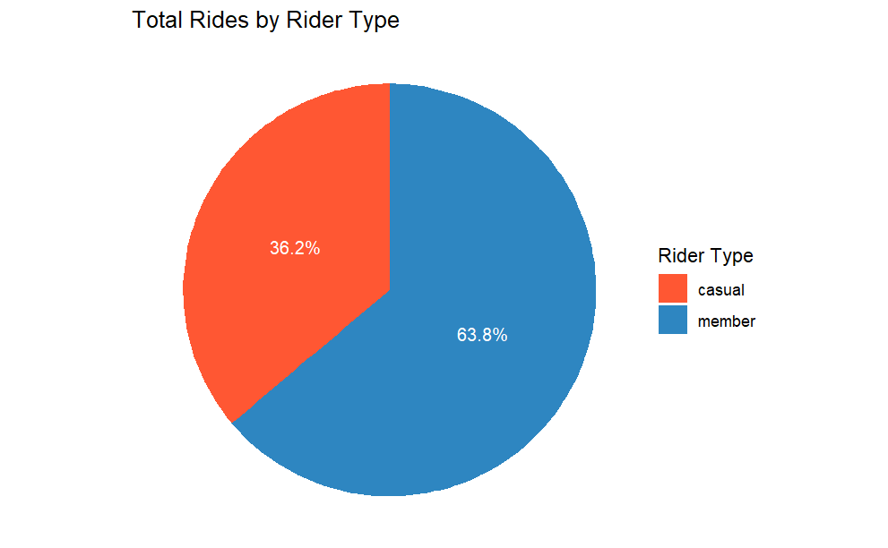

```r
# Visualize total rides for each rider type.
usage_stats <- usage_stats %>%
  mutate(percentage = total_rides / sum(total_rides) * 100)

# Create a pie chart with percentage labels
ggplot(usage_stats, aes(x = "", y = total_rides, fill = member_casual)) +
  geom_bar(stat = "identity", width = 1) +
  coord_polar("y", start = 0) +
  geom_text(
    aes(label = paste0(round(percentage, 1), "%")),
      position = position_stack(vjust = 0.5),
      color = "white", size = 3.5) +
  scale_fill_manual(values = c("casual" = color_casual, "member" = color_member)) +
  labs(
    title = "Total Rides by Rider Type",
    fill = "Rider Type"
  ) +
  theme_void()
```

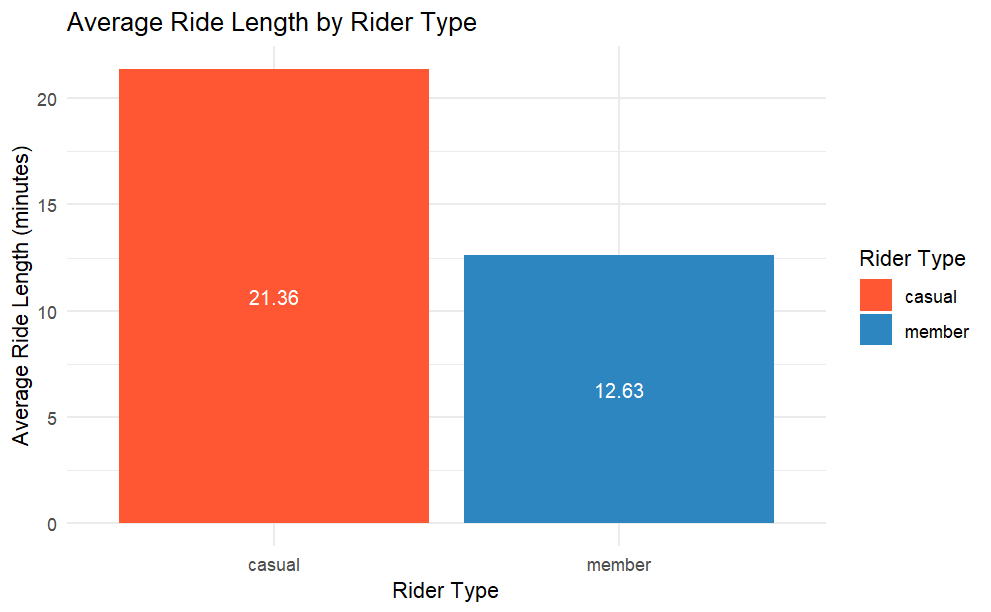

```r
# Visualize average ride length for each rider type.
ggplot(usage_stats,aes(x = member_casual, y = (average_ride_length / 60), fill = member_casual)) +
  geom_bar(stat = "identity") +
  geom_text(aes(label = sprintf("%.2f", average_ride_length / 60)),
    position = position_stack(vjust = 0.5),
    color = "white", size = 3.5) +
  scale_fill_manual(values = c("casual" = color_casual, "member" = color_member)) +
  labs(
    title = "Average Ride Length by Rider Type",
    x = "Rider Type",
    y = "Average Ride Length (minutes)",
    fill = "Rider Type"
    ) +
  theme_minimal()
```

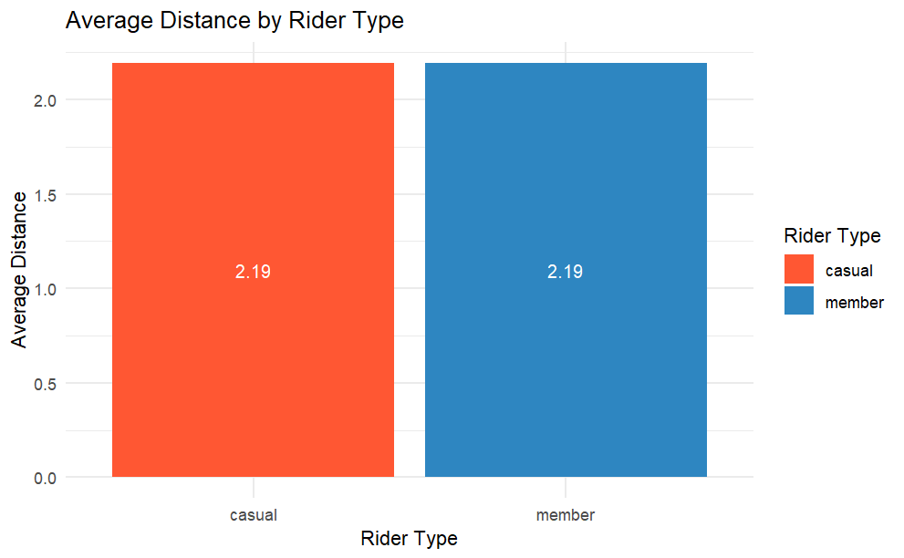

```r
# Visualize average trip distance for each rider type.
ggplot(usage_stats,aes(x = member_casual, y = average_distance, fill = member_casual)) +
  geom_bar(stat = "identity") +
  geom_text(aes(label = sprintf("%.2f", average_distance)),
    position = position_stack(vjust = 0.5),
    color = "white", size = 3.5) +
  scale_fill_manual(values = c("casual" = color_casual, "member" = color_member)) +
  labs(
    title = "Average Distance by Rider Type",
    x = "Rider Type",
    y = "Average Distance",
    fill = "Rider Type"
    ) +
  theme_minimal()
```

### **Temporal Analysis**

**Ride Frequency by Day of the Week**

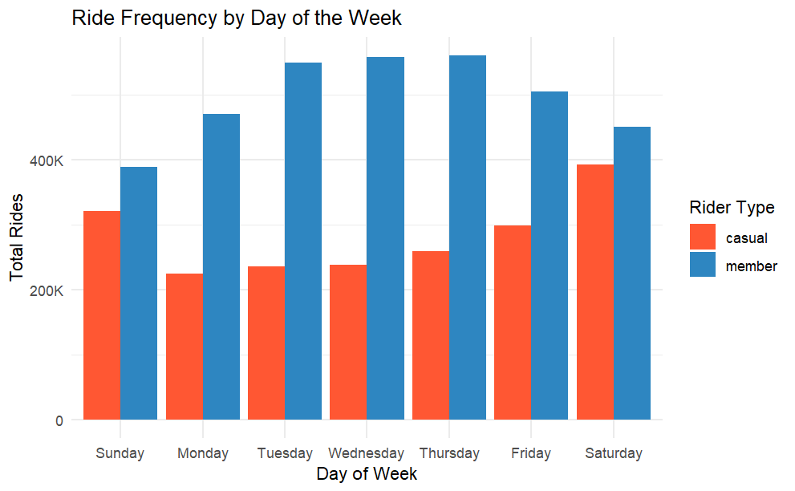

```r
# Find the ride frequency by day of week by rider type.
ride_freq_by_day_of_week <- cyclistic_data %>%
  group_by(member_casual, day_of_week) %>%
  summarise(
    total_rides = n(),
    .groups = "drop"
  )

# Visualize ride frequency by day of week.
ggplot(
  ride_freq_by_day_of_week,
  aes(
    x = day_of_week,
    y = total_rides,
    fill = member_casual
  )
) +
  geom_bar(stat = "identity", position = "dodge") +
  scale_y_continuous(labels = format_k_m) +
  scale_fill_manual(values = c("casual" = color_casual, "member" = color_member)) +
  labs(
    title = "Ride Frequency by Day of the Week",
    x = "Day of Week",
    y = "Total Rides",
    fill = "Rider Type"
  ) +
  theme_minimal()
```

**Ride Frequency During Peak Hours**

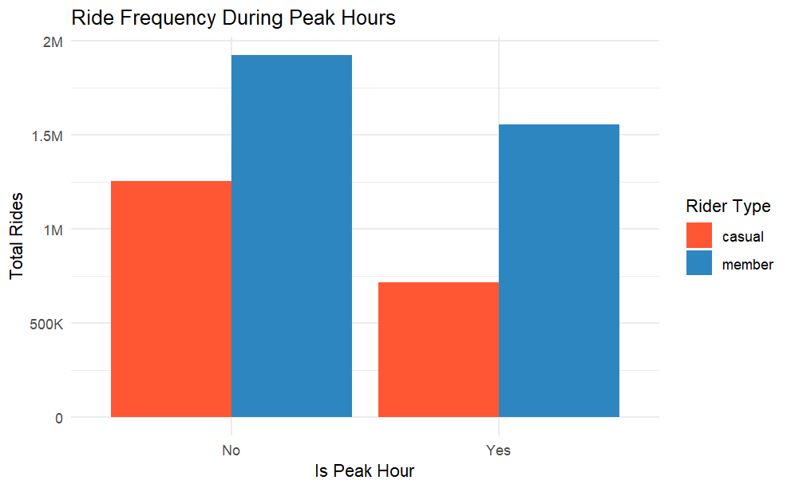

```r
# Find the peak hour usage by rider type.
peak_hour_stats <- cyclistic_data %>%
  group_by(member_casual, is_peak_hour) %>%
  summarise(total_rides = n(),
            .groups = "drop")

# Visualize ride frequency by day of week.
ggplot(
  peak_hour_stats,
  aes(
    x = is_peak_hour,
    y = total_rides,
    fill = member_casual
  )
) +
  geom_bar(stat = "identity", position = "dodge") +
  scale_y_continuous(labels = format_k_m) +
  scale_fill_manual(values = c("casual" = color_casual, "member" = color_member)) +
  labs(
    title = "Ride Frequency During Peak Hours",
    x = "Is Peak Hour",
    y = "Total Rides",
    fill = "Rider Type"
  ) +
  theme_minimal()
```

**Ride Frequency (Weekday vs. Weekend)**

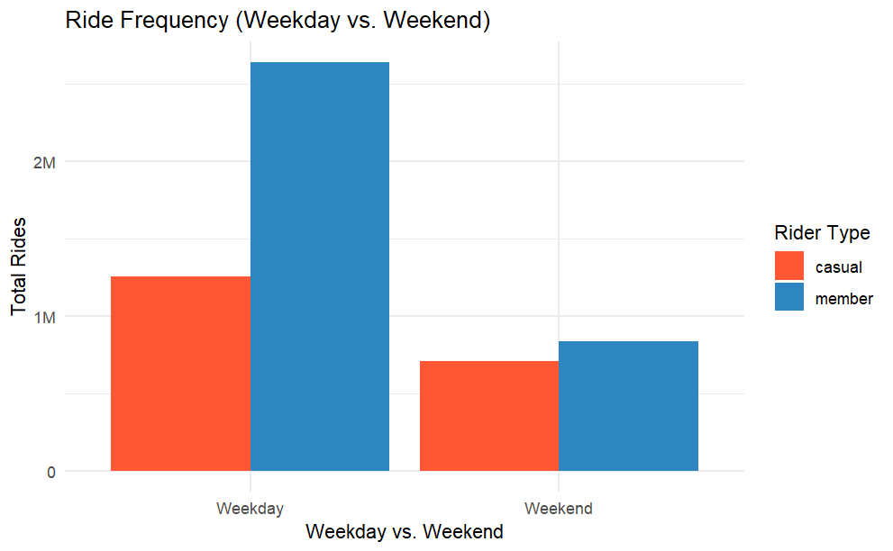

```r
# Find the ride frequency on weekends and weekdays by rider type.
weekend_weekday_stats <- cyclistic_data %>%
    mutate(weekday_weekend = if_else(
      is_weekend == "Yes", "Weekend", "Weekday")) %>%
  group_by(member_casual, weekday_weekend) %>%
  summarise(total_rides = n(),
            .groups = 'drop')

# Visualize ride frequency by weekdays vs weekends.
ggplot(
  weekend_weekday_stats,
  aes(
    x = weekday_weekend,
    y = total_rides,
    fill = member_casual
  )
) +
  geom_bar(stat = "identity", position = "dodge") +
  scale_y_continuous(labels = format_k_m) +
  scale_fill_manual(values = c("casual" = color_casual, "member" = color_member)) +
  labs(
    title = "Ride Frequency (Weekday vs. Weekend)",
    x = "Weekday vs. Weekend",
    y = "Total Rides",
    fill = "Rider Type"
  ) +
  theme_minimal()
```

**Ride Frequency by Part of Day**

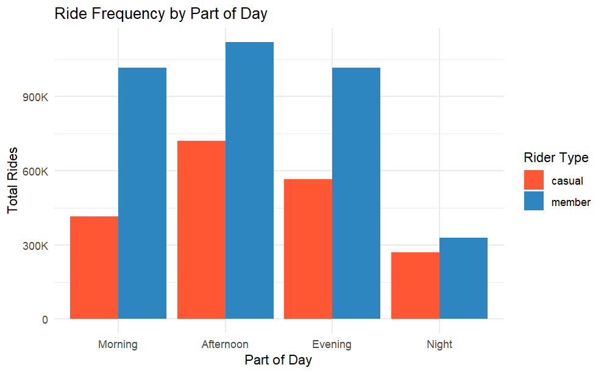

```r
# Find the ride frequency by part of day by rider type.
day_parts_stats <- cyclistic_data %>%
  mutate(day_part = factor(
    day_part, levels = c("Morning", "Afternoon", "Evening", "Night"))) %>%
  group_by(member_casual, day_part) %>%
  summarise(total_rides = n(),
            .groups = "drop")

# Visualize ride frequency by part of day.
ggplot(
  day_parts_stats,
  aes(
    x = day_part,
    y = total_rides,
    fill = member_casual
  )
) +
  geom_bar(stat = "identity", position = "dodge") +
  scale_y_continuous(labels = format_k_m) +
  scale_fill_manual(values = c("casual" = color_casual, "member" = color_member)) +
  labs(
    title = "Ride Frequency by Part of Day",
    x = "Part of Day",
    y = "Total Rides",
    fill = "Rider Type"
  ) +
  theme_minimal()
```

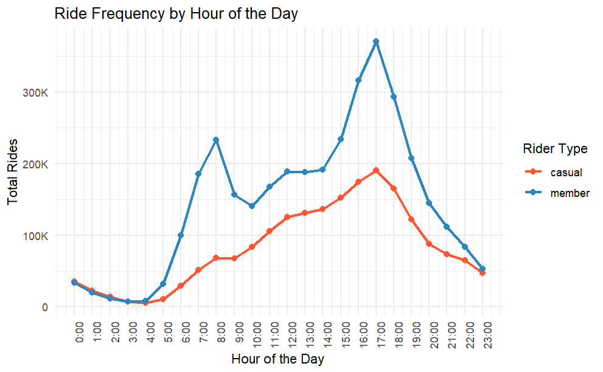

```r
# Extract the hour from the 'started_at' column
cyclistic_data <- cyclistic_data %>%
  mutate(hour = hour(started_at))

# Summarize the total rides by hour and rider type
rides_by_hour <- cyclistic_data %>%
  group_by(member_casual, hour) %>%
  summarise(total_rides = n(),
            .groups = "drop")

# Create the line chart
ggplot(rides_by_hour, aes(x = hour, y = total_rides, color = member_casual, group = member_casual)) +
  geom_line(size = 1) +
  geom_point(size = 2) +
  scale_color_manual(values = c("casual" = color_casual, "member" = color_member)) +
  scale_x_continuous(breaks = 0:23, labels = paste0(0:23, ":00")) +
  scale_y_continuous(labels = format_k_m) +
  labs(
    title = "Ride Frequency by Hour of the Day",
    x = "Hour of the Day",
    y = "Total Rides",
    color = "Rider Type"
  ) +
  theme_minimal() +
  theme(axis.text.x = element_text(angle = 90, hjust = 1))
```

### **Seasonal Trends**

**Rides by Season**

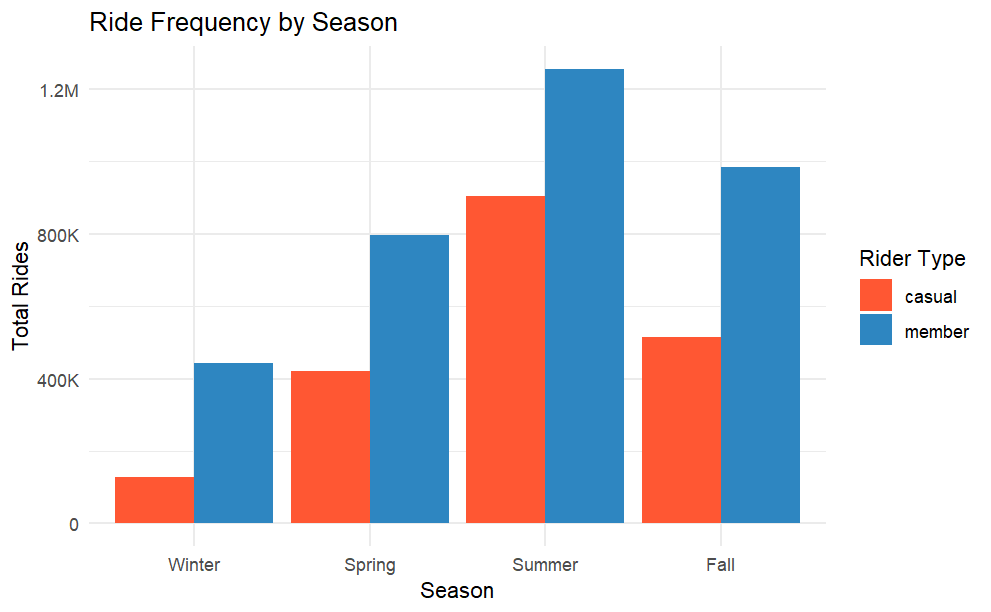

```r
# Find the ride frequency by season by rider type.
season_stats <- cyclistic_data %>%
  mutate(season = factor(
  season, levels = c("Winter", "Spring", "Summer", "Fall"))) %>%
  group_by(member_casual, season) %>%
  summarise(total_rides = n(),
            .groups = "drop")

# Visualize ride frequency by season.
ggplot(
  season_stats,
  aes(
    x = season,
    y = total_rides,
    fill = member_casual
  )
) +
  geom_bar(stat = "identity", position = "dodge") +
  scale_y_continuous(labels = format_k_m) +
  scale_fill_manual(values = c("casual" = color_casual, "member" = color_member)) +
  labs(
    title = "Ride Frequency by Season",
    x = "Season",
    y = "Total Rides",
    fill = "Rider Type"
  ) +
  theme_minimal()
```